# Extra_Attempted_Work

## Extra Attempted Work

As mentioned in the **"Feature_Engeering"** notebook, there are some techniques and algorithms that we tried to implement but failed due to lack of computational power. In this notebook, we will discuss two such cases, one from each, text mining and network mining approach.

- **Latent Dirichlet Allocation**

LDA is a probabilistic model where each topic is considered as a mixture of words and each document is considered as a mixture of topics. Using LDA, we will attempt to identify the latent topics from our corpus of text that make up the comments.

```python
# Loading the required libraries

# Data manipulation
import numpy as np
import pandas as pd

# Visualisation
import matplotlib.pyplot as plt
import seaborn as sns
sns.set(style='whitegrid', context='talk')
from wordcloud import WordCloud


# Text preprocessing and modelling
import nltk
from nltk.tokenize import word_tokenize
from nltk.tokenize import RegexpTokenizer
from nltk import pos_tag
from nltk.stem import WordNetLemmatizer
from nltk.corpus import stopwords
from sklearn.feature_extraction.text import ENGLISH_STOP_WORDS
from sklearn.model_selection import train_test_split, GridSearchCV
from sklearn.feature_extraction.text import CountVectorizer
from sklearn.decomposition import LatentDirichletAllocation
from sklearn.pipeline import Pipeline
from tqdm.auto import tqdm
```

```python
df = pd.read_pickle('/Users/moharcd/Desktop/Web_Mining/Project/final_features.pkl')
```

```python
df[['body_cleaned']]
```

|  | body_cleaned |
| --- | --- |
| 0 | kid reminds kevin sad |
| 1 | im guy idea thing guys |
| 2 | honestly wouldnt believed didnt live made life... |
| 3 | money id driver license credit cards subway st... |
| 4 | thats one reason one major one increased incid... |
| ... | ... |
| 4234965 | oh gosh freaked kid |
| 4234966 | glasses case oh dear |
| 4234967 | oh silly case paul blart mall cop |
| 4234968 | oh case dont know |
| 4234969 | oh yay want talk |

4234970 rows × 1 columns

```python
df.columns
```

```
Index(['created_utc', 'ups', 'subreddit_id', 'link_id', 'name', 'subreddit',
       'id', 'author', 'body', 'parent_id', 'body_deleted', 'author_deleted',
       'comment_count_author', 'is_AutoModerator', 'time', 'time_elapse',
       'hour_of_comment', 'weekday', 'word_count', 'linked_urls',
       'no_of_linked_urls', 'depth', 'parent_author', 'degree_author',
       'eigenVector_author', 'degree', 'eigenVector', 'body_cleaned',
       'word_count_cleaned', 'Hard_Cluster', 'author_hard_clusters',
       'author_nb_hard_clusters', 'contains_?', 'contains_!',
       'degree_author_topic'],
      dtype='object')
```

The body is already cleaned in the feature engeering.

We take a very small subset to illustrate the algorithm.

```python
sample = df.head(100)
```

As a first step, we will transform the text data into numeric data using bag-of-words approach. The easiest way to make this transformation is to use `CountVectorizer()` from sklearn:

```python
# Convert to document-term matrix
vectoriser = CountVectorizer(stop_words='english')
matrix = vectoriser.fit_transform(sample['body_cleaned'])
```

```python
# Extract feature/term names
feature_names = vectoriser.get_feature_names()
```

```python
# Inspect document-term matrix
pd.DataFrame.sparse.from_spmatrix(matrix,columns=feature_names)
```

|  | _____________ | ability | able | academic | accent | accept | account | accusations | accused | accuser | ... | yes | york | youd | youngster | youre | youve | yyyymmdd | zebrasharks | zoom | zoop |
| --- | --- | --- | --- | --- | --- | --- | --- | --- | --- | --- | --- | --- | --- | --- | --- | --- | --- | --- | --- | --- | --- |
| 0 | 0 | 0 | 0 | 0 | 0 | 0 | 0 | 0 | 0 | 0 | ... | 0 | 0 | 0 | 0 | 0 | 0 | 0 | 0 | 0 | 0 |
| 1 | 0 | 0 | 0 | 0 | 0 | 0 | 0 | 0 | 0 | 0 | ... | 0 | 0 | 0 | 0 | 0 | 0 | 0 | 0 | 0 | 0 |
| 2 | 0 | 0 | 0 | 0 | 0 | 0 | 0 | 0 | 0 | 0 | ... | 0 | 0 | 0 | 0 | 0 | 0 | 0 | 0 | 0 | 0 |
| 3 | 0 | 0 | 0 | 0 | 0 | 0 | 0 | 0 | 0 | 0 | ... | 0 | 0 | 0 | 0 | 0 | 0 | 0 | 0 | 0 | 0 |
| 4 | 0 | 0 | 0 | 0 | 0 | 0 | 0 | 0 | 0 | 0 | ... | 0 | 0 | 0 | 0 | 0 | 0 | 0 | 0 | 0 | 0 |
| ... | ... | ... | ... | ... | ... | ... | ... | ... | ... | ... | ... | ... | ... | ... | ... | ... | ... | ... | ... | ... | ... |
| 95 | 0 | 0 | 0 | 0 | 0 | 0 | 0 | 0 | 0 | 0 | ... | 0 | 0 | 0 | 0 | 0 | 0 | 0 | 0 | 0 | 0 |
| 96 | 0 | 0 | 0 | 0 | 0 | 0 | 0 | 0 | 0 | 0 | ... | 0 | 0 | 0 | 0 | 0 | 0 | 0 | 0 | 0 | 0 |
| 97 | 0 | 0 | 0 | 0 | 0 | 0 | 0 | 0 | 0 | 0 | ... | 0 | 0 | 0 | 0 | 0 | 0 | 0 | 0 | 0 | 0 |
| 98 | 0 | 0 | 0 | 0 | 0 | 0 | 0 | 0 | 0 | 0 | ... | 0 | 0 | 0 | 0 | 0 | 0 | 0 | 0 | 0 | 0 |
| 99 | 0 | 0 | 0 | 0 | 0 | 0 | 0 | 0 | 0 | 0 | ... | 0 | 0 | 0 | 0 | 0 | 0 | 0 | 0 | 0 | 0 |

100 rows × 1014 columns

Does not look very clean, but we have to keep in mind that we are dealing with comments which can be very informal. People often make typos or use reddit/text specific lingo.

Let’s now **vectorise** (i.e. transform into numerical representation) the training documents. To be more practical, let’s pretend we don’t know the number of topics and we will attempt to find the suitable number of topics using grid search. If you have an intuitive guess on the rough range of topics, one way to narrow down the options is to run grid search. However, take the output of grid search as a guide only and check if the topics make sense.

```python
# Run grid search across parameters of choice
lda = LatentDirichletAllocation(learning_method='online', random_state=0)
param_grid = {'n_components': [10,20, 30, 40, 50]}
lda_search = GridSearchCV(lda, param_grid=param_grid, cv=3)
lda_search.fit(matrix)
```

```
GridSearchCV(cv=3,
             estimator=LatentDirichletAllocation(learning_method='online',
                                                 random_state=0),
             param_grid={'n_components': [10, 20, 30, 40, 50]})
```

```python
# Inspect grid search output
results = pd.DataFrame(lda_search.cv_results_)\
            .sort_values("rank_test_score")
results[['param_n_components', "rank_test_score", 'mean_test_score',
         'std_test_score']]
```

|  | param_n_components | rank_test_score | mean_test_score | std_test_score |
| --- | --- | --- | --- | --- |
| 0 | 10 | 1 | -9035.903847 | 946.946446 |
| 1 | 20 | 2 | -19890.946949 | 1001.653030 |
| 2 | 30 | 3 | -35110.747211 | 1009.769445 |
| 3 | 40 | 4 | -53369.872276 | 1036.382899 |
| 4 | 50 | 5 | -74101.362654 | 1042.966185 |

```python
# Build LDA model
lda = LatentDirichletAllocation(n_components=10, random_state=0,learning_method='online')
lda.fit(matrix)
```

```
LatentDirichletAllocation(learning_method='online', random_state=0)
```

```python
columns = ['topic'+str(i+1) for i in range(10)]
sample[columns]= lda.transform(matrix)
sample.head(5)
```

|  | created_utc | ups | subreddit_id | link_id | name | subreddit | id | author | body | parent_id | ... | topic1 | topic2 | topic3 | topic4 | topic5 | topic6 | topic7 | topic8 | topic9 | topic10 |
| --- | --- | --- | --- | --- | --- | --- | --- | --- | --- | --- | --- | --- | --- | --- | --- | --- | --- | --- | --- | --- | --- |
| 0 | 1430438400 | 3.0 | t5_2qh1i | t3_34fvry | t1_cqug90k | AskReddit | cqug90k | beltfedshooter | That the kid ..reminds me of Kevin. so sad :-( | t3_34fvry | ... | 0.020000 | 0.819997 | 0.020001 | 0.020000 | 0.020000 | 0.020000 | 0.020000 | 0.020000 | 0.020000 | 0.020000 |
| 1 | 1430438401 | 1.0 | t5_2qh1i | t3_34aqsn | t1_cqug91c | AskReddit | cqug91c | JuanTutrego | I'm a guy and I had no idea this was a thing g... | t1_cqtdj4m | ... | 0.016673 | 0.016668 | 0.016668 | 0.849982 | 0.016667 | 0.016667 | 0.016669 | 0.016667 | 0.016669 | 0.016669 |
| 2 | 1430438402 | -5.0 | t5_2qh1i | t3_34fvry | t1_cqug921 | AskReddit | cqug921 | youthfulvictim | I honestly wouldn't have believed it if I didn... | t1_cqug6hk | ... | 0.006250 | 0.006250 | 0.006250 | 0.943748 | 0.006250 | 0.006250 | 0.006250 | 0.006250 | 0.006250 | 0.006250 |
| 3 | 1430438402 | 1.0 | t5_2qh1i | t3_34gmo3 | t1_cqug929 | AskReddit | cqug929 | boludo54 | no money, just ID, driver license, credit card... | t3_34gmo3 | ... | 0.011111 | 0.011111 | 0.011111 | 0.011111 | 0.011111 | 0.899998 | 0.011111 | 0.011112 | 0.011111 | 0.011111 |
| 4 | 1430438403 | 1.0 | t5_2qh1i | t3_34gmgb | t1_cqug937 | AskReddit | cqug937 | hamhead | That's one reason for it, but not the only one... | t3_34gmgb | ... | 0.010001 | 0.010000 | 0.010000 | 0.909998 | 0.010000 | 0.010000 | 0.010000 | 0.010001 | 0.010000 | 0.010000 |

5 rows × 45 columns

Great, we will now identify the dominant topic by finding the topic with the highest probability for each record:

```python
sample['Top'] = sample.iloc[:, 34:44].idxmax(axis=1)
sample['Probability'] = sample.iloc[:, 34:44].max(axis=1)
sample
```

[output not shown]

100 rows × 50 columns

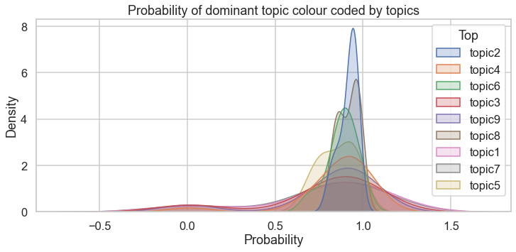

```python
plt.figure(figsize=(12,5))
sns.kdeplot(data=sample, x='Probability', hue='Top', shade=True,
            common_norm=False)
plt.title("Probability of dominant topic colour coded by topics");
```

This result was expected. Again, we are dealing with comments, and especially comments of a forum where users ask questions of varied topics. We are dealing with the AskReddit subreddit, so there are bound to be a plethora of topics. Had we worked with r/wallstreetbets, maybe the topic distinction would have been better. But, nevertheless, great to see that majority of the values are close to 1.

- **Network Mining**

### A- Authors

One interesting feature in predicting the popularity of a comment can be the popularity of the author. Basically, an author who interacts with lots of authors is more likely to have his comment visible and seen by others, therefore it's more likely to be upvoted or downvoted.

#### 1- Building the Graph

Clearly, as we want to model the interactions between authors, we model our graph in a way that:

- Nodes represent Authors
- Edges represent link between authors, which exists when two authors have the same parent_link, i.e, comment on the same comment

```python
data_graph.columns
```

```python
# We start by importing the Network package
import networkx as nx
```

```python
# We then start by creating an undirected graph joining authors
G1 = nx.Graph()
```

```python
# We then add nodes related to authors
G1.add_nodes_from(data_graph.author, type="author")
```

```python
# We calculate the number of nodes
len(list(G1.nodes))
```

[output not shown]

```python
# We check if it's the same number of authors
len(data_graph.author.unique())
```

[output not shown]

```python
# We check that we have the same number of authors, i.e, no author was duplicated
len(data_graph.author.unique())
```

```python
list(G1.nodes)[0]
```

```python
# We then add edges where the condition is that two authors have commented on the same comment
# have common parent_ids
```

```python
# To create the links we first look again at the columns of the data
data.columns
```

```python
# This big for loop aims at establishing links between authors who have common parent_id
# So we want to tell the loop to follow the following steps

# Start by iterating over the list of authors,

# first step
# for i in range(len(G1.nodes)-1):
    # for j in range(i+1,len(G1.nodes)):
        #author_1 = list(G1.nodes)[i]
        #author_2 = list(G1.nodes)[j] #Check the author that is next

    # Now we give the condition to establish the link,
    # We have to iterate over the list of parent ids of each others
        #parents_1 = list(data_graph.loc[data_graph.author==author_1].parent_id)
        #parents_2 = list(data_graph.loc[data_graph.author==author_2].parent_id)

    # We give the condition to establish a link between authors only when we find a common parent_id
        # for parent1 in parents_1:
        # for parent2 in parents_2:
            # if parent1 == parent2:
                # G1.add_edge(i,j,"Linked")
                # break
```

```python
# Mini example on how to find for each author for a specific parent id

# We start by getting the unique parent_ids,
data_graph.parent_id.unique()
```

```python
# One particular element
data_graph.parent_id.unique()[0]
```

```python
# Getting the list of all authors who have the same parent_id
list(data_graph.loc[data_graph.parent_id=='t1_cqug2sr'].author)
```

```python
import time
from tqdm import tqdm
```

```python
# To easen the computations we drop the rows for which the parent_id has only one author
data_graph.head()
```

```python
# Can we do a group by table ?
data_graph_authors = data_graph.set_index('parent_id')
```

```python
data_graph_authors['author']
```

```python
# Adding a column that counts the number of times a parent_id appread
test=data_graph.groupby(['parent_id','author'])
test.head()
```

```python
# So we move to another solution,

# We start by creating a dictionnary in which we will put for each parent_id the list of authors

# Initializing the dictionnary
authors_parents = dict()
for parent in tqdm(data_graph.parent_id.unique()):
    authors_parents[parent]= list(data_graph.loc[data_graph.parent_id==parent].author)
```

The aim here was to link the authors who have the same parent id, by using the "add_edges" networkx function later, but as we didn't succeed with the first step due to the heavy computations required, and after checking with Professor Yoann, it was not possible to build the network in this way.